# Case Study

Samarth

2022-07-23

## Introduction:-

This case study involes the analysis of historical data for a hypothetical company called Cyclistic, a Chicago-based bike sharing company. In order to answer the key business questions, you will follow the steps of the data analysis process: ask, prepare, process, analyze,share, and act.

## Scenario:-

You are a junior data analyst working in the marketing analyst team at Cyclistic, a bike-share company in Chicago. The director of marketing believes the company’s future success depends on maximizing the number of annual memberships. Therefore, your team wants to understand how casual riders and annual members use Cyclistic bikes differently. From these insights, your team will design a new marketing strategy to convert casual riders into annual members. But first, Cyclistic executives must approve your recommendations, so they must be backed up with compelling data insights and professional data visualizations.

## Characters and teams:-

● Cyclistic: A bike-share program that features more than 5,800 bicycles and 600 docking stations. Cyclistic sets itself apart by also offering reclining bikes, hand tricycles, and cargo bikes, making bike-share more inclusive to people with disabilities and riders who can’t use a standard two-wheeled bike. The majority of riders opt for traditional bikes; about 8% of riders use the assistive options. Cyclistic users are more likely to ride for leisure, but about 30% use them to commute to work each day.

● Lily Moreno: The director of marketing and your manager. Moreno is responsible for the development of campaigns and initiatives to promote the bike-share program. These may include email, social media, and other channels.

● Cyclistic marketing analytics team: A team of data analysts who are responsible for collecting, analyzing, and reporting data that helps guide Cyclistic marketing strategy. You joined this team six months ago and have been busy learning about Cyclistic’s mission and business goals — as well as how you, as a junior data analyst, can help Cyclistic achieve them.

● Cyclistic executive team: The notoriously detail-oriented executive team will decide whether to approve the recommended marketing program.

## 1. Ask

Business Objective

Through a targeted marketing approach, to increase revenue by converting casual riders into annual members.

Business Task The junior analyst has been tasked with answering the following question: “How do annual members and casual riders use Cyclistic bikes differently?”

Stakeholders Involved The stakeholders involved in this project are: Director of Marketing at Cyclistic : Lily Moreno, responsible for the marketing campaigns at Cyclistic.

The Cyclistic marketing team, responsible with collecting and analysing and reporting data.

The Cyclistic management team. This group makes the ultimate decision on the marketing strategy that has been recommended. They are known for their meticulous attention to detail.

## 2. Prepare

In Rideable_type Field column Docked bike type need some explation so that it could make sense to the audience. The latitude and longitude coordinates for the stations are also an issue. It’s not difficult to make a list of popular stations, but mapping them is more complicated.I also found that some values are missing which we decided to eliminate from our analysis.

##3. Process and Clean

Tools used - 1) R-Dekstop to analyze, clean, perform calculation and visualization.

Integrity of Dataset - I examined the 12 month dataset for the overall idea of the case and I tried to check for the common errors which can be present in the dataset.

```
     I found --
    i) Missing values in the start and end stations variables
    ii)  Missing values in the end_lat, end_lgt, start_lat and start_lgt
    iii) Duplicate records in ride_ID variable
    iv) Too long or too short values in the ride duration variable
```

### Load required packages

```r
library(tidyverse) #helps wrangle data
library(lubridate) #helps wrangle date attributes
```

```r
library(ggplot2)   #for data visualization
library(skimr)     #for summary statistics about variable in data frames.
library(janitor)   # provide quick count of variable
library(scales)    # map data to aesthetics, and provide methods for automatically determining breaks and labels for axes and legends.
library(mapview)   # For interactive visualisations of spatial data with or without background maps
```

### sets your working directory

```r
getwd()
```

```
## [1] "C:/Users/hp/OneDrive/Desktop/Data Analysis/Course 8/Project 1/Original files"
```

```r
setwd("C:/Users/hp/OneDrive/Desktop/Data Analysis/Course 8/Project 1/Original files")
```

### Upload Divvy datasets (csv files) here

```r
jan <- read_csv("202101-divvy-tripdata.csv")
feb <- read_csv("202102-divvy-tripdata.csv")
mar <- read_csv("202103-divvy-tripdata.csv")
apr <- read_csv("202104-divvy-tripdata.csv")
may <- read_csv("202105-divvy-tripdata.csv")
jun <- read_csv("202106-divvy-tripdata.csv")
july <- read_csv("202107-divvy-tripdata.csv")
aug <- read_csv("202108-divvy-tripdata.csv")
sept <- read_csv("202109-divvy-tripdata.csv")
oct <- read_csv("202110-divvy-tripdata.csv")
nov <- read_csv("202111-divvy-tripdata.csv")
dec <- read_csv("202112-divvy-tripdata.csv")
```

### Compare column names each of the files

```r
colnames(jan)
```

```
##  [1] "ride_id"            "rideable_type"      "started_at"
##  [4] "ended_at"           "start_station_name" "start_station_id"
##  [7] "end_station_name"   "end_station_id"     "start_lat"
## [10] "start_lng"          "end_lat"            "end_lng"
## [13] "member_casual"
```

```r
colnames(feb)
```

```
##  [1] "ride_id"            "rideable_type"      "started_at"
##  [4] "ended_at"           "start_station_name" "start_station_id"
##  [7] "end_station_name"   "end_station_id"     "start_lat"
## [10] "start_lng"          "end_lat"            "end_lng"
## [13] "member_casual"
```

```r
colnames(mar)
```

```
##  [1] "ride_id"            "rideable_type"      "started_at"
##  [4] "ended_at"           "start_station_name" "start_station_id"
##  [7] "end_station_name"   "end_station_id"     "start_lat"
## [10] "start_lng"          "end_lat"            "end_lng"
## [13] "member_casual"
```

```r
colnames(apr)
```

```
##  [1] "ride_id"            "rideable_type"      "started_at"
##  [4] "ended_at"           "start_station_name" "start_station_id"
##  [7] "end_station_name"   "end_station_id"     "start_lat"
## [10] "start_lng"          "end_lat"            "end_lng"
## [13] "member_casual"
```

```r
colnames(may)
```

```
##  [1] "ride_id"            "rideable_type"      "started_at"
##  [4] "ended_at"           "start_station_name" "start_station_id"
##  [7] "end_station_name"   "end_station_id"     "start_lat"
## [10] "start_lng"          "end_lat"            "end_lng"
## [13] "member_casual"
```

```r
colnames(jun)
```

```
##  [1] "ride_id"            "rideable_type"      "started_at"
##  [4] "ended_at"           "start_station_name" "start_station_id"
##  [7] "end_station_name"   "end_station_id"     "start_lat"
## [10] "start_lng"          "end_lat"            "end_lng"
## [13] "member_casual"
```

```r
colnames(july)
```

```
##  [1] "ride_id"            "rideable_type"      "started_at"
##  [4] "ended_at"           "start_station_name" "start_station_id"
##  [7] "end_station_name"   "end_station_id"     "start_lat"
## [10] "start_lng"          "end_lat"            "end_lng"
## [13] "member_casual"
```

```r
colnames(aug)
```

```
##  [1] "ride_id"            "rideable_type"      "started_at"
##  [4] "ended_at"           "start_station_name" "start_station_id"
##  [7] "end_station_name"   "end_station_id"     "start_lat"
## [10] "start_lng"          "end_lat"            "end_lng"
## [13] "member_casual"
```

```r
colnames(sept)
```

```
##  [1] "ride_id"            "rideable_type"      "started_at"
##  [4] "ended_at"           "start_station_name" "start_station_id"
##  [7] "end_station_name"   "end_station_id"     "start_lat"
## [10] "start_lng"          "end_lat"            "end_lng"
## [13] "member_casual"
```

```r
colnames(oct)
```

```
##  [1] "ride_id"            "rideable_type"      "started_at"
##  [4] "ended_at"           "start_station_name" "start_station_id"
##  [7] "end_station_name"   "end_station_id"     "start_lat"
## [10] "start_lng"          "end_lat"            "end_lng"
## [13] "member_casual"
```

```r
colnames(nov)
```

```
##  [1] "ride_id"            "rideable_type"      "started_at"
##  [4] "ended_at"           "start_station_name" "start_station_id"
##  [7] "end_station_name"   "end_station_id"     "start_lat"
## [10] "start_lng"          "end_lat"            "end_lng"
## [13] "member_casual"
```

```r
colnames(dec)
```

```
##  [1] "ride_id"            "rideable_type"      "started_at"
##  [4] "ended_at"           "start_station_name" "start_station_id"
##  [7] "end_station_name"   "end_station_id"     "start_lat"
## [10] "start_lng"          "end_lat"            "end_lng"
## [13] "member_casual"
```

### Inspect the dataframes and look for incongruencies.See list of columns and data types (numeric, character, etc)

```r
str(jan)
```

```
## spec_tbl_df [96,834 × 13] (S3: spec_tbl_df/tbl_df/tbl/data.frame)
##  $ ride_id           : chr [1:96834] "E19E6F1B8D4C42ED" "DC88F20C2C55F27F" "EC45C94683FE3F27" "4FA453A75AE377DB" ...
##  $ rideable_type     : chr [1:96834] "electric_bike" "electric_bike" "electric_bike" "electric_bike" ...
##  $ started_at        : POSIXct[1:96834], format: "2021-01-23 16:14:19" "2021-01-27 18:43:08" ...
##  $ ended_at          : POSIXct[1:96834], format: "2021-01-23 16:24:44" "2021-01-27 18:47:12" ...
##  $ start_station_name: chr [1:96834] "California Ave & Cortez St" "California Ave & Cortez St" "California Ave & Cortez St" "California Ave & Cortez St" ...
##  $ start_station_id  : chr [1:96834] "17660" "17660" "17660" "17660" ...
##  $ end_station_name  : chr [1:96834] NA NA NA NA ...
##  $ end_station_id    : chr [1:96834] NA NA NA NA ...
##  $ start_lat         : num [1:96834] 41.9 41.9 41.9 41.9 41.9 ...
##  $ start_lng         : num [1:96834] -87.7 -87.7 -87.7 -87.7 -87.7 ...
##  $ end_lat           : num [1:96834] 41.9 41.9 41.9 41.9 41.9 ...
##  $ end_lng           : num [1:96834] -87.7 -87.7 -87.7 -87.7 -87.7 ...
##  $ member_casual     : chr [1:96834] "member" "member" "member" "member" ...
##  - attr(*, "spec")=
##   .. cols(
##   ..   ride_id = col_character(),
##   ..   rideable_type = col_character(),
##   ..   started_at = col_datetime(format = ""),
##   ..   ended_at = col_datetime(format = ""),
##   ..   start_station_name = col_character(),
##   ..   start_station_id = col_character(),
##   ..   end_station_name = col_character(),
##   ..   end_station_id = col_character(),
##   ..   start_lat = col_double(),
##   ..   start_lng = col_double(),
##   ..   end_lat = col_double(),
##   ..   end_lng = col_double(),
##   ..   member_casual = col_character()
##   .. )
##  - attr(*, "problems")=<externalptr>
```

```r
str(feb)
```

```
## spec_tbl_df [49,622 × 13] (S3: spec_tbl_df/tbl_df/tbl/data.frame)
##  $ ride_id           : chr [1:49622] "89E7AA6C29227EFF" "0FEFDE2603568365" "E6159D746B2DBB91" "B32D3199F1C2E75B" ...
##  $ rideable_type     : chr [1:49622] "classic_bike" "classic_bike" "electric_bike" "classic_bike" ...
##  $ started_at        : POSIXct[1:49622], format: "2021-02-12 16:14:56" "2021-02-14 17:52:38" ...
##  $ ended_at          : POSIXct[1:49622], format: "2021-02-12 16:21:43" "2021-02-14 18:12:09" ...
##  $ start_station_name: chr [1:49622] "Glenwood Ave & Touhy Ave" "Glenwood Ave & Touhy Ave" "Clark St & Lake St" "Wood St & Chicago Ave" ...
##  $ start_station_id  : chr [1:49622] "525" "525" "KA1503000012" "637" ...
##  $ end_station_name  : chr [1:49622] "Sheridan Rd & Columbia Ave" "Bosworth Ave & Howard St" "State St & Randolph St" "Honore St & Division St" ...
##  $ end_station_id    : chr [1:49622] "660" "16806" "TA1305000029" "TA1305000034" ...
##  $ start_lat         : num [1:49622] 42 42 41.9 41.9 41.8 ...
##  $ start_lng         : num [1:49622] -87.7 -87.7 -87.6 -87.7 -87.6 ...
##  $ end_lat           : num [1:49622] 42 42 41.9 41.9 41.8 ...
##  $ end_lng           : num [1:49622] -87.7 -87.7 -87.6 -87.7 -87.6 ...
##  $ member_casual     : chr [1:49622] "member" "casual" "member" "member" ...
##  - attr(*, "spec")=
##   .. cols(
##   ..   ride_id = col_character(),
##   ..   rideable_type = col_character(),
##   ..   started_at = col_datetime(format = ""),
##   ..   ended_at = col_datetime(format = ""),
##   ..   start_station_name = col_character(),
##   ..   start_station_id = col_character(),
##   ..   end_station_name = col_character(),
##   ..   end_station_id = col_character(),
##   ..   start_lat = col_double(),
##   ..   start_lng = col_double(),
##   ..   end_lat = col_double(),
##   ..   end_lng = col_double(),
##   ..   member_casual = col_character()
##   .. )
##  - attr(*, "problems")=<externalptr>
```

```r
str(mar)
```

```
## spec_tbl_df [228,496 × 13] (S3: spec_tbl_df/tbl_df/tbl/data.frame)
##  $ ride_id           : chr [1:228496] "CFA86D4455AA1030" "30D9DC61227D1AF3" "846D87A15682A284" "994D05AA75A168F2" ...
##  $ rideable_type     : chr [1:228496] "classic_bike" "classic_bike" "classic_bike" "classic_bike" ...
##  $ started_at        : POSIXct[1:228496], format: "2021-03-16 08:32:30" "2021-03-28 01:26:28" ...
##  $ ended_at          : POSIXct[1:228496], format: "2021-03-16 08:36:34" "2021-03-28 01:36:55" ...
##  $ start_station_name: chr [1:228496] "Humboldt Blvd & Armitage Ave" "Humboldt Blvd & Armitage Ave" "Shields Ave & 28th Pl" "Winthrop Ave & Lawrence Ave" ...
##  $ start_station_id  : chr [1:228496] "15651" "15651" "15443" "TA1308000021" ...
##  $ end_station_name  : chr [1:228496] "Stave St & Armitage Ave" "Central Park Ave & Bloomingdale Ave" "Halsted St & 35th St" "Broadway & Sheridan Rd" ...
##  $ end_station_id    : chr [1:228496] "13266" "18017" "TA1308000043" "13323" ...
##  $ start_lat         : num [1:228496] 41.9 41.9 41.8 42 42 ...
##  $ start_lng         : num [1:228496] -87.7 -87.7 -87.6 -87.7 -87.7 ...
##  $ end_lat           : num [1:228496] 41.9 41.9 41.8 42 42.1 ...
##  $ end_lng           : num [1:228496] -87.7 -87.7 -87.6 -87.6 -87.7 ...
##  $ member_casual     : chr [1:228496] "casual" "casual" "casual" "casual" ...
##  - attr(*, "spec")=
##   .. cols(
##   ..   ride_id = col_character(),
##   ..   rideable_type = col_character(),
##   ..   started_at = col_datetime(format = ""),
##   ..   ended_at = col_datetime(format = ""),
##   ..   start_station_name = col_character(),
##   ..   start_station_id = col_character(),
##   ..   end_station_name = col_character(),
##   ..   end_station_id = col_character(),
##   ..   start_lat = col_double(),
##   ..   start_lng = col_double(),
##   ..   end_lat = col_double(),
##   ..   end_lng = col_double(),
##   ..   member_casual = col_character()
##   .. )
##  - attr(*, "problems")=<externalptr>
```

```r
str(apr)
```

```
## spec_tbl_df [337,230 × 13] (S3: spec_tbl_df/tbl_df/tbl/data.frame)
##  $ ride_id           : chr [1:337230] "6C992BD37A98A63F" "1E0145613A209000" "E498E15508A80BAD" "1887262AD101C604" ...
##  $ rideable_type     : chr [1:337230] "classic_bike" "docked_bike" "docked_bike" "classic_bike" ...
##  $ started_at        : POSIXct[1:337230], format: "2021-04-12 18:25:36" "2021-04-27 17:27:11" ...
##  $ ended_at          : POSIXct[1:337230], format: "2021-04-12 18:56:55" "2021-04-27 18:31:29" ...
##  $ start_station_name: chr [1:337230] "State St & Pearson St" "Dorchester Ave & 49th St" "Loomis Blvd & 84th St" "Honore St & Division St" ...
##  $ start_station_id  : chr [1:337230] "TA1307000061" "KA1503000069" "20121" "TA1305000034" ...
##  $ end_station_name  : chr [1:337230] "Southport Ave & Waveland Ave" "Dorchester Ave & 49th St" "Loomis Blvd & 84th St" "Southport Ave & Waveland Ave" ...
##  $ end_station_id    : chr [1:337230] "13235" "KA1503000069" "20121" "13235" ...
##  $ start_lat         : num [1:337230] 41.9 41.8 41.7 41.9 41.7 ...
##  $ start_lng         : num [1:337230] -87.6 -87.6 -87.7 -87.7 -87.7 ...
##  $ end_lat           : num [1:337230] 41.9 41.8 41.7 41.9 41.7 ...
##  $ end_lng           : num [1:337230] -87.7 -87.6 -87.7 -87.7 -87.7 ...
##  $ member_casual     : chr [1:337230] "member" "casual" "casual" "member" ...
##  - attr(*, "spec")=
##   .. cols(
##   ..   ride_id = col_character(),
##   ..   rideable_type = col_character(),
##   ..   started_at = col_datetime(format = ""),
##   ..   ended_at = col_datetime(format = ""),
##   ..   start_station_name = col_character(),
##   ..   start_station_id = col_character(),
##   ..   end_station_name = col_character(),
##   ..   end_station_id = col_character(),
##   ..   start_lat = col_double(),
##   ..   start_lng = col_double(),
##   ..   end_lat = col_double(),
##   ..   end_lng = col_double(),
##   ..   member_casual = col_character()
##   .. )
##  - attr(*, "problems")=<externalptr>
```

```r
str(may)
```

```
## spec_tbl_df [531,633 × 13] (S3: spec_tbl_df/tbl_df/tbl/data.frame)
##  $ ride_id           : chr [1:531633] "C809ED75D6160B2A" "DD59FDCE0ACACAF3" "0AB83CB88C43EFC2" "7881AC6D39110C60" ...
##  $ rideable_type     : chr [1:531633] "electric_bike" "electric_bike" "electric_bike" "electric_bike" ...
##  $ started_at        : POSIXct[1:531633], format: "2021-05-30 11:58:15" "2021-05-30 11:29:14" ...
##  $ ended_at          : POSIXct[1:531633], format: "2021-05-30 12:10:39" "2021-05-30 12:14:09" ...
##  $ start_station_name: chr [1:531633] NA NA NA NA ...
##  $ start_station_id  : chr [1:531633] NA NA NA NA ...
##  $ end_station_name  : chr [1:531633] NA NA NA NA ...
##  $ end_station_id    : chr [1:531633] NA NA NA NA ...
##  $ start_lat         : num [1:531633] 41.9 41.9 41.9 41.9 41.9 ...
##  $ start_lng         : num [1:531633] -87.6 -87.6 -87.7 -87.7 -87.7 ...
##  $ end_lat           : num [1:531633] 41.9 41.8 41.9 41.9 41.9 ...
##  $ end_lng           : num [1:531633] -87.6 -87.6 -87.7 -87.7 -87.7 ...
##  $ member_casual     : chr [1:531633] "casual" "casual" "casual" "casual" ...
##  - attr(*, "spec")=
##   .. cols(
##   ..   ride_id = col_character(),
##   ..   rideable_type = col_character(),
##   ..   started_at = col_datetime(format = ""),
##   ..   ended_at = col_datetime(format = ""),
##   ..   start_station_name = col_character(),
##   ..   start_station_id = col_character(),
##   ..   end_station_name = col_character(),
##   ..   end_station_id = col_character(),
##   ..   start_lat = col_double(),
##   ..   start_lng = col_double(),
##   ..   end_lat = col_double(),
##   ..   end_lng = col_double(),
##   ..   member_casual = col_character()
##   .. )
##  - attr(*, "problems")=<externalptr>
```

```r
str(jun)
```

```
## spec_tbl_df [729,595 × 13] (S3: spec_tbl_df/tbl_df/tbl/data.frame)
##  $ ride_id           : chr [1:729595] "99FEC93BA843FB20" "06048DCFC8520CAF" "9598066F68045DF2" "B03C0FE48C412214" ...
##  $ rideable_type     : chr [1:729595] "electric_bike" "electric_bike" "electric_bike" "electric_bike" ...
##  $ started_at        : POSIXct[1:729595], format: "2021-06-13 14:31:28" "2021-06-04 11:18:02" ...
##  $ ended_at          : POSIXct[1:729595], format: "2021-06-13 14:34:11" "2021-06-04 11:24:19" ...
##  $ start_station_name: chr [1:729595] NA NA NA NA ...
##  $ start_station_id  : chr [1:729595] NA NA NA NA ...
##  $ end_station_name  : chr [1:729595] NA NA NA NA ...
##  $ end_station_id    : chr [1:729595] NA NA NA NA ...
##  $ start_lat         : num [1:729595] 41.8 41.8 41.8 41.8 41.8 ...
##  $ start_lng         : num [1:729595] -87.6 -87.6 -87.6 -87.6 -87.6 ...
##  $ end_lat           : num [1:729595] 41.8 41.8 41.8 41.8 41.8 ...
##  $ end_lng           : num [1:729595] -87.6 -87.6 -87.6 -87.6 -87.6 ...
##  $ member_casual     : chr [1:729595] "member" "member" "member" "member" ...
##  - attr(*, "spec")=
##   .. cols(
##   ..   ride_id = col_character(),
##   ..   rideable_type = col_character(),
##   ..   started_at = col_datetime(format = ""),
##   ..   ended_at = col_datetime(format = ""),
##   ..   start_station_name = col_character(),
##   ..   start_station_id = col_character(),
##   ..   end_station_name = col_character(),
##   ..   end_station_id = col_character(),
##   ..   start_lat = col_double(),
##   ..   start_lng = col_double(),
##   ..   end_lat = col_double(),
##   ..   end_lng = col_double(),
##   ..   member_casual = col_character()
##   .. )
##  - attr(*, "problems")=<externalptr>
```

```r
str(july)
```

```
## spec_tbl_df [822,410 × 13] (S3: spec_tbl_df/tbl_df/tbl/data.frame)
##  $ ride_id           : chr [1:822410] "0A1B623926EF4E16" "B2D5583A5A5E76EE" "6F264597DDBF427A" "379B58EAB20E8AA5" ...
##  $ rideable_type     : chr [1:822410] "docked_bike" "classic_bike" "classic_bike" "classic_bike" ...
##  $ started_at        : chr [1:822410] "02-07-2021 14:44" "07-07-2021 16:57" "25-07-2021 11:30" "08-07-2021 22:08" ...
##  $ ended_at          : chr [1:822410] "02-07-2021 15:19" "07-07-2021 17:16" "25-07-2021 11:48" "08-07-2021 22:23" ...
##  $ start_station_name: chr [1:822410] "Michigan Ave & Washington St" "California Ave & Cortez St" "Wabash Ave & 16th St" "California Ave & Cortez St" ...
##  $ start_station_id  : chr [1:822410] "13001" "17660" "SL-012" "17660" ...
##  $ end_station_name  : chr [1:822410] "Halsted St & North Branch St" "Wood St & Hubbard St" "Rush St & Hubbard St" "Carpenter St & Huron St" ...
##  $ end_station_id    : chr [1:822410] "KA1504000117" "13432" "KA1503000044" "13196" ...
##  $ start_lat         : num [1:822410] 41.9 41.9 41.9 41.9 41.9 ...
##  $ start_lng         : num [1:822410] -87.6 -87.7 -87.6 -87.7 -87.7 ...
##  $ end_lat           : num [1:822410] 41.9 41.9 41.9 41.9 41.9 ...
##  $ end_lng           : num [1:822410] -87.6 -87.7 -87.6 -87.7 -87.7 ...
##  $ member_casual     : chr [1:822410] "casual" "casual" "member" "member" ...
##  - attr(*, "spec")=
##   .. cols(
##   ..   ride_id = col_character(),
##   ..   rideable_type = col_character(),
##   ..   started_at = col_character(),
##   ..   ended_at = col_character(),
##   ..   start_station_name = col_character(),
##   ..   start_station_id = col_character(),
##   ..   end_station_name = col_character(),
##   ..   end_station_id = col_character(),
##   ..   start_lat = col_double(),
##   ..   start_lng = col_double(),
##   ..   end_lat = col_double(),
##   ..   end_lng = col_double(),
##   ..   member_casual = col_character()
##   .. )
##  - attr(*, "problems")=<externalptr>
```

```r
str(aug)
```

```
## spec_tbl_df [804,352 × 13] (S3: spec_tbl_df/tbl_df/tbl/data.frame)
##  $ ride_id           : chr [1:804352] "99103BB87CC6C1BB" "EAFCCCFB0A3FC5A1" "9EF4F46C57AD234D" "5834D3208BFAF1DA" ...
##  $ rideable_type     : chr [1:804352] "electric_bike" "electric_bike" "electric_bike" "electric_bike" ...
##  $ started_at        : POSIXct[1:804352], format: "2021-08-10 17:15:49" "2021-08-10 17:23:14" ...
##  $ ended_at          : POSIXct[1:804352], format: "2021-08-10 17:22:44" "2021-08-10 17:39:24" ...
##  $ start_station_name: chr [1:804352] NA NA NA NA ...
##  $ start_station_id  : chr [1:804352] NA NA NA NA ...
##  $ end_station_name  : chr [1:804352] NA NA NA NA ...
##  $ end_station_id    : chr [1:804352] NA NA NA NA ...
##  $ start_lat         : num [1:804352] 41.8 41.8 42 42 41.8 ...
##  $ start_lng         : num [1:804352] -87.7 -87.7 -87.7 -87.7 -87.6 ...
##  $ end_lat           : num [1:804352] 41.8 41.8 42 42 41.8 ...
##  $ end_lng           : num [1:804352] -87.7 -87.6 -87.7 -87.7 -87.6 ...
##  $ member_casual     : chr [1:804352] "member" "member" "member" "member" ...
##  - attr(*, "spec")=
##   .. cols(
##   ..   ride_id = col_character(),
##   ..   rideable_type = col_character(),
##   ..   started_at = col_datetime(format = ""),
##   ..   ended_at = col_datetime(format = ""),
##   ..   start_station_name = col_character(),
##   ..   start_station_id = col_character(),
##   ..   end_station_name = col_character(),
##   ..   end_station_id = col_character(),
##   ..   start_lat = col_double(),
##   ..   start_lng = col_double(),
##   ..   end_lat = col_double(),
##   ..   end_lng = col_double(),
##   ..   member_casual = col_character()
##   .. )
##  - attr(*, "problems")=<externalptr>
```

```r
str(sept)
```

```
## spec_tbl_df [756,147 × 13] (S3: spec_tbl_df/tbl_df/tbl/data.frame)
##  $ ride_id           : chr [1:756147] "9DC7B962304CBFD8" "F930E2C6872D6B32" "6EF72137900BB910" "78D1DE133B3DBF55" ...
##  $ rideable_type     : chr [1:756147] "electric_bike" "electric_bike" "electric_bike" "electric_bike" ...
##  $ started_at        : POSIXct[1:756147], format: "2021-09-28 16:07:10" "2021-09-28 14:24:51" ...
##  $ ended_at          : POSIXct[1:756147], format: "2021-09-28 16:09:54" "2021-09-28 14:40:05" ...
##  $ start_station_name: chr [1:756147] NA NA NA NA ...
##  $ start_station_id  : chr [1:756147] NA NA NA NA ...
##  $ end_station_name  : chr [1:756147] NA NA NA NA ...
##  $ end_station_id    : chr [1:756147] NA NA NA NA ...
##  $ start_lat         : num [1:756147] 41.9 41.9 41.8 41.8 41.9 ...
##  $ start_lng         : num [1:756147] -87.7 -87.6 -87.7 -87.7 -87.7 ...
##  $ end_lat           : num [1:756147] 41.9 42 41.8 41.8 41.9 ...
##  $ end_lng           : num [1:756147] -87.7 -87.7 -87.7 -87.7 -87.7 ...
##  $ member_casual     : chr [1:756147] "casual" "casual" "casual" "casual" ...
##  - attr(*, "spec")=
##   .. cols(
##   ..   ride_id = col_character(),
##   ..   rideable_type = col_character(),
##   ..   started_at = col_datetime(format = ""),
##   ..   ended_at = col_datetime(format = ""),
##   ..   start_station_name = col_character(),
##   ..   start_station_id = col_character(),
##   ..   end_station_name = col_character(),
##   ..   end_station_id = col_character(),
##   ..   start_lat = col_double(),
##   ..   start_lng = col_double(),
##   ..   end_lat = col_double(),
##   ..   end_lng = col_double(),
##   ..   member_casual = col_character()
##   .. )
##  - attr(*, "problems")=<externalptr>
```

```r
str(oct)
```

```
## spec_tbl_df [631,226 × 13] (S3: spec_tbl_df/tbl_df/tbl/data.frame)
##  $ ride_id           : chr [1:631226] "620BC6107255BF4C" "4471C70731AB2E45" "26CA69D43D15EE14" "362947F0437E1514" ...
##  $ rideable_type     : chr [1:631226] "electric_bike" "electric_bike" "electric_bike" "electric_bike" ...
##  $ started_at        : POSIXct[1:631226], format: "2021-10-22 12:46:42" "2021-10-21 09:12:37" ...
##  $ ended_at          : POSIXct[1:631226], format: "2021-10-22 12:49:50" "2021-10-21 09:14:14" ...
##  $ start_station_name: chr [1:631226] "Kingsbury St & Kinzie St" NA NA NA ...
##  $ start_station_id  : chr [1:631226] "KA1503000043" NA NA NA ...
##  $ end_station_name  : chr [1:631226] NA NA NA NA ...
##  $ end_station_id    : chr [1:631226] NA NA NA NA ...
##  $ start_lat         : num [1:631226] 41.9 41.9 41.9 41.9 41.9 ...
##  $ start_lng         : num [1:631226] -87.6 -87.7 -87.7 -87.7 -87.7 ...
##  $ end_lat           : num [1:631226] 41.9 41.9 41.9 41.9 41.9 ...
##  $ end_lng           : num [1:631226] -87.6 -87.7 -87.7 -87.7 -87.7 ...
##  $ member_casual     : chr [1:631226] "member" "member" "member" "member" ...
##  - attr(*, "spec")=
##   .. cols(
##   ..   ride_id = col_character(),
##   ..   rideable_type = col_character(),
##   ..   started_at = col_datetime(format = ""),
##   ..   ended_at = col_datetime(format = ""),
##   ..   start_station_name = col_character(),
##   ..   start_station_id = col_character(),
##   ..   end_station_name = col_character(),
##   ..   end_station_id = col_character(),
##   ..   start_lat = col_double(),
##   ..   start_lng = col_double(),
##   ..   end_lat = col_double(),
##   ..   end_lng = col_double(),
##   ..   member_casual = col_character()
##   .. )
##  - attr(*, "problems")=<externalptr>
```

```r
str(nov)
```

```
## spec_tbl_df [359,978 × 13] (S3: spec_tbl_df/tbl_df/tbl/data.frame)
##  $ ride_id           : chr [1:359978] "7C00A93E10556E47" "90854840DFD508BA" "0A7D10CDD144061C" "2F3BE33085BCFF02" ...
##  $ rideable_type     : chr [1:359978] "electric_bike" "electric_bike" "electric_bike" "electric_bike" ...
##  $ started_at        : POSIXct[1:359978], format: "2021-11-27 13:27:38" "2021-11-27 13:38:25" ...
##  $ ended_at          : POSIXct[1:359978], format: "2021-11-27 13:46:38" "2021-11-27 13:56:10" ...
##  $ start_station_name: chr [1:359978] NA NA NA NA ...
##  $ start_station_id  : chr [1:359978] NA NA NA NA ...
##  $ end_station_name  : chr [1:359978] NA NA NA NA ...
##  $ end_station_id    : chr [1:359978] NA NA NA NA ...
##  $ start_lat         : num [1:359978] 41.9 42 42 41.9 41.9 ...
##  $ start_lng         : num [1:359978] -87.7 -87.7 -87.7 -87.8 -87.6 ...
##  $ end_lat           : num [1:359978] 42 41.9 42 41.9 41.9 ...
##  $ end_lng           : num [1:359978] -87.7 -87.7 -87.7 -87.8 -87.6 ...
##  $ member_casual     : chr [1:359978] "casual" "casual" "casual" "casual" ...
##  - attr(*, "spec")=
##   .. cols(
##   ..   ride_id = col_character(),
##   ..   rideable_type = col_character(),
##   ..   started_at = col_datetime(format = ""),
##   ..   ended_at = col_datetime(format = ""),
##   ..   start_station_name = col_character(),
##   ..   start_station_id = col_character(),
##   ..   end_station_name = col_character(),
##   ..   end_station_id = col_character(),
##   ..   start_lat = col_double(),
##   ..   start_lng = col_double(),
##   ..   end_lat = col_double(),
##   ..   end_lng = col_double(),
##   ..   member_casual = col_character()
##   .. )
##  - attr(*, "problems")=<externalptr>
```

```r
str(dec)
```

```
## spec_tbl_df [247,540 × 13] (S3: spec_tbl_df/tbl_df/tbl/data.frame)
##  $ ride_id           : chr [1:247540] "46F8167220E4431F" "73A77762838B32FD" "4CF42452054F59C5" "3278BA87BF698339" ...
##  $ rideable_type     : chr [1:247540] "electric_bike" "electric_bike" "electric_bike" "classic_bike" ...
##  $ started_at        : POSIXct[1:247540], format: "2021-12-07 15:06:07" "2021-12-11 03:43:29" ...
##  $ ended_at          : POSIXct[1:247540], format: "2021-12-07 15:13:42" "2021-12-11 04:10:23" ...
##  $ start_station_name: chr [1:247540] "Laflin St & Cullerton St" "LaSalle Dr & Huron St" "Halsted St & North Branch St" "Halsted St & North Branch St" ...
##  $ start_station_id  : chr [1:247540] "13307" "KP1705001026" "KA1504000117" "KA1504000117" ...
##  $ end_station_name  : chr [1:247540] "Morgan St & Polk St" "Clarendon Ave & Leland Ave" "Broadway & Barry Ave" "LaSalle Dr & Huron St" ...
##  $ end_station_id    : chr [1:247540] "TA1307000130" "TA1307000119" "13137" "KP1705001026" ...
##  $ start_lat         : num [1:247540] 41.9 41.9 41.9 41.9 41.9 ...
##  $ start_lng         : num [1:247540] -87.7 -87.6 -87.6 -87.6 -87.7 ...
##  $ end_lat           : num [1:247540] 41.9 42 41.9 41.9 41.9 ...
##  $ end_lng           : num [1:247540] -87.7 -87.7 -87.6 -87.6 -87.6 ...
##  $ member_casual     : chr [1:247540] "member" "casual" "member" "member" ...
##  - attr(*, "spec")=
##   .. cols(
##   ..   ride_id = col_character(),
##   ..   rideable_type = col_character(),
##   ..   started_at = col_datetime(format = ""),
##   ..   ended_at = col_datetime(format = ""),
##   ..   start_station_name = col_character(),
##   ..   start_station_id = col_character(),
##   ..   end_station_name = col_character(),
##   ..   end_station_id = col_character(),
##   ..   start_lat = col_double(),
##   ..   start_lng = col_double(),
##   ..   end_lat = col_double(),
##   ..   end_lng = col_double(),
##   ..   member_casual = col_character()
##   .. )
##  - attr(*, "problems")=<externalptr>
```

```r
july <- mutate(july, started_at = as.POSIXct(started_at), ended_at = as.POSIXct(ended_at))

str(july)
```

```
## tibble [822,410 × 13] (S3: tbl_df/tbl/data.frame)
##  $ ride_id           : chr [1:822410] "0A1B623926EF4E16" "B2D5583A5A5E76EE" "6F264597DDBF427A" "379B58EAB20E8AA5" ...
##  $ rideable_type     : chr [1:822410] "docked_bike" "classic_bike" "classic_bike" "classic_bike" ...
##  $ started_at        : POSIXct[1:822410], format: "0002-07-20" "0007-07-20" ...
##  $ ended_at          : POSIXct[1:822410], format: "0002-07-20" "0007-07-20" ...
##  $ start_station_name: chr [1:822410] "Michigan Ave & Washington St" "California Ave & Cortez St" "Wabash Ave & 16th St" "California Ave & Cortez St" ...
##  $ start_station_id  : chr [1:822410] "13001" "17660" "SL-012" "17660" ...
##  $ end_station_name  : chr [1:822410] "Halsted St & North Branch St" "Wood St & Hubbard St" "Rush St & Hubbard St" "Carpenter St & Huron St" ...
##  $ end_station_id    : chr [1:822410] "KA1504000117" "13432" "KA1503000044" "13196" ...
##  $ start_lat         : num [1:822410] 41.9 41.9 41.9 41.9 41.9 ...
##  $ start_lng         : num [1:822410] -87.6 -87.7 -87.6 -87.7 -87.7 ...
##  $ end_lat           : num [1:822410] 41.9 41.9 41.9 41.9 41.9 ...
##  $ end_lng           : num [1:822410] -87.6 -87.7 -87.6 -87.7 -87.7 ...
##  $ member_casual     : chr [1:822410] "casual" "casual" "member" "member" ...
```

### Combining each month dataset into one big data frame

```r
trips <- bind_rows(feb, mar, apr, may, jun, july, aug, sept, oct, nov, dec, jan)
```

### To get detailed information about trips dataset

```r
colnames(trips)
```

```
##  [1] "ride_id"            "rideable_type"      "started_at"
##  [4] "ended_at"           "start_station_name" "start_station_id"
##  [7] "end_station_name"   "end_station_id"     "start_lat"
## [10] "start_lng"          "end_lat"            "end_lng"
## [13] "member_casual"
```

```r
glimpse(trips)
```

```
## Rows: 5,595,063
## Columns: 13
## $ ride_id            <chr> "89E7AA6C29227EFF", "0FEFDE2603568365", "E6159D746B…
## $ rideable_type      <chr> "classic_bike", "classic_bike", "electric_bike", "c…
## $ started_at         <dttm> 2021-02-12 16:14:56, 2021-02-14 17:52:38, 2021-02-…
## $ ended_at           <dttm> 2021-02-12 16:21:43, 2021-02-14 18:12:09, 2021-02-…
## $ start_station_name <chr> "Glenwood Ave & Touhy Ave", "Glenwood Ave & Touhy A…
## $ start_station_id   <chr> "525", "525", "KA1503000012", "637", "13216", "1800…
## $ end_station_name   <chr> "Sheridan Rd & Columbia Ave", "Bosworth Ave & Howar…
## $ end_station_id     <chr> "660", "16806", "TA1305000029", "TA1305000034", "TA…
## $ start_lat          <dbl> 42.01270, 42.01270, 41.88579, 41.89563, 41.83473, 4…
## $ start_lng          <dbl> -87.66606, -87.66606, -87.63110, -87.67207, -87.625…
## $ end_lat            <dbl> 42.00458, 42.01954, 41.88487, 41.90312, 41.83816, 4…
## $ end_lng            <dbl> -87.66141, -87.66956, -87.62750, -87.67394, -87.645…
## $ member_casual      <chr> "member", "casual", "member", "member", "member", "…
```

```r
nrow(trips)
```

```
## [1] 5595063
```

```r
dim(trips)
```

```
## [1] 5595063      13
```

```r
head(trips)
```

```
## # A tibble: 6 × 13
##   ride_id rideable_type started_at          ended_at            start_station_n…
##   <chr>   <chr>         <dttm>              <dttm>              <chr>
## 1 89E7AA… classic_bike  2021-02-12 16:14:56 2021-02-12 16:21:43 Glenwood Ave & …
## 2 0FEFDE… classic_bike  2021-02-14 17:52:38 2021-02-14 18:12:09 Glenwood Ave & …
## 3 E6159D… electric_bike 2021-02-09 19:10:18 2021-02-09 19:19:10 Clark St & Lake…
## 4 B32D31… classic_bike  2021-02-02 17:49:41 2021-02-02 17:54:06 Wood St & Chica…
## 5 83E463… electric_bike 2021-02-23 15:07:23 2021-02-23 15:22:37 State St & 33rd…
## 6 BDAA7E… electric_bike 2021-02-24 15:43:33 2021-02-24 15:49:05 Fairbanks St & …
## # … with 8 more variables: start_station_id <chr>, end_station_name <chr>,
## #   end_station_id <chr>, start_lat <dbl>, start_lng <dbl>, end_lat <dbl>,
## #   end_lng <dbl>, member_casual <chr>
```

```r
summary(trips)
```

```
##    ride_id          rideable_type        started_at
##  Length:5595063     Length:5595063     Min.   :0001-07-19 18:06:32.00
##  Class :character   Class :character   1st Qu.:2021-04-18 14:50:13.50
##  Mode  :character   Mode  :character   Median :2021-08-01 01:52:11.00
##                                        Mean   :1726-11-28 22:21:51.90
##                                        3rd Qu.:2021-09-24 16:36:16.00
##                                        Max.   :2021-12-31 23:59:48.00
##
##     ended_at                      start_station_name start_station_id
##  Min.   :0001-07-19 18:06:32.00   Length:5595063     Length:5595063
##  1st Qu.:2021-04-18 15:19:20.00   Class :character   Class :character
##  Median :2021-08-01 02:15:23.00   Mode  :character   Mode  :character
##  Mean   :1726-11-28 10:07:44.31
##  3rd Qu.:2021-09-24 16:54:05.50
##  Max.   :2022-01-03 17:32:18.00
##
##  end_station_name   end_station_id       start_lat       start_lng
##  Length:5595063     Length:5595063     Min.   :41.64   Min.   :-87.84
##  Class :character   Class :character   1st Qu.:41.88   1st Qu.:-87.66
##  Mode  :character   Mode  :character   Median :41.90   Median :-87.64
##                                        Mean   :41.90   Mean   :-87.65
##                                        3rd Qu.:41.93   3rd Qu.:-87.63
##                                        Max.   :42.07   Max.   :-87.52
##
##     end_lat         end_lng       member_casual
##  Min.   :41.39   Min.   :-88.97   Length:5595063
##  1st Qu.:41.88   1st Qu.:-87.66   Class :character
##  Median :41.90   Median :-87.64   Mode  :character
##  Mean   :41.90   Mean   :-87.65
##  3rd Qu.:41.93   3rd Qu.:-87.63
##  Max.   :42.17   Max.   :-87.49
##  NA's   :4771    NA's   :4771
```

### To get total number observations under each user-type

```r
table(trips$member_casual)
```

```
##
##  casual  member
## 2529005 3066058
```

### 2529005 3066058

### Removed empty columns and rows

```r
trips <- trips %>%
  remove_empty(which = c("cols", "rows"))
```

### The following variables have been transformed from character to numeric variables

```r
trips <- trips %>%
  mutate(start_lat = as.numeric(start_lat), start_lng = as.numeric(start_lng), end_lat = as.numeric(end_lat), end_lng = as.numeric(end_lng))

glimpse(trips)
```

```
## Rows: 5,595,063
## Columns: 13
## $ ride_id            <chr> "89E7AA6C29227EFF", "0FEFDE2603568365", "E6159D746B…
## $ rideable_type      <chr> "classic_bike", "classic_bike", "electric_bike", "c…
## $ started_at         <dttm> 2021-02-12 16:14:56, 2021-02-14 17:52:38, 2021-02-…
## $ ended_at           <dttm> 2021-02-12 16:21:43, 2021-02-14 18:12:09, 2021-02-…
## $ start_station_name <chr> "Glenwood Ave & Touhy Ave", "Glenwood Ave & Touhy A…
## $ start_station_id   <chr> "525", "525", "KA1503000012", "637", "13216", "1800…
## $ end_station_name   <chr> "Sheridan Rd & Columbia Ave", "Bosworth Ave & Howar…
## $ end_station_id     <chr> "660", "16806", "TA1305000029", "TA1305000034", "TA…
## $ start_lat          <dbl> 42.01270, 42.01270, 41.88579, 41.89563, 41.83473, 4…
## $ start_lng          <dbl> -87.66606, -87.66606, -87.63110, -87.67207, -87.625…
## $ end_lat            <dbl> 42.00458, 42.01954, 41.88487, 41.90312, 41.83816, 4…
## $ end_lng            <dbl> -87.66141, -87.66956, -87.62750, -87.67394, -87.645…
## $ member_casual      <chr> "member", "casual", "member", "member", "member", "…
```

### Investigate the NA values in the data frame

```r
colSums(is.na(trips))
```

```
##            ride_id      rideable_type         started_at           ended_at
##                  0                  0                  0                  0
## start_station_name   start_station_id   end_station_name     end_station_id
##             690809             690806             739170             739170
##          start_lat          start_lng            end_lat            end_lng
##                  0                  0               4771               4771
##      member_casual
##                  0
```

### Evaluate a statistical summary of the data frame

```r
trips %>%
  summary()
```

```
##    ride_id          rideable_type        started_at
##  Length:5595063     Length:5595063     Min.   :0001-07-19 18:06:32.00
##  Class :character   Class :character   1st Qu.:2021-04-18 14:50:13.50
##  Mode  :character   Mode  :character   Median :2021-08-01 01:52:11.00
##                                        Mean   :1726-11-28 22:21:51.90
##                                        3rd Qu.:2021-09-24 16:36:16.00
##                                        Max.   :2021-12-31 23:59:48.00
##
##     ended_at                      start_station_name start_station_id
##  Min.   :0001-07-19 18:06:32.00   Length:5595063     Length:5595063
##  1st Qu.:2021-04-18 15:19:20.00   Class :character   Class :character
##  Median :2021-08-01 02:15:23.00   Mode  :character   Mode  :character
##  Mean   :1726-11-28 10:07:44.31
##  3rd Qu.:2021-09-24 16:54:05.50
##  Max.   :2022-01-03 17:32:18.00
##
##  end_station_name   end_station_id       start_lat       start_lng
##  Length:5595063     Length:5595063     Min.   :41.64   Min.   :-87.84
##  Class :character   Class :character   1st Qu.:41.88   1st Qu.:-87.66
##  Mode  :character   Mode  :character   Median :41.90   Median :-87.64
##                                        Mean   :41.90   Mean   :-87.65
##                                        3rd Qu.:41.93   3rd Qu.:-87.63
##                                        Max.   :42.07   Max.   :-87.52
##
##     end_lat         end_lng       member_casual
##  Min.   :41.39   Min.   :-88.97   Length:5595063
##  1st Qu.:41.88   1st Qu.:-87.66   Class :character
##  Median :41.90   Median :-87.64   Mode  :character
##  Mean   :41.90   Mean   :-87.65
##  3rd Qu.:41.93   3rd Qu.:-87.63
##  Max.   :42.17   Max.   :-87.49
##  NA's   :4771    NA's   :4771
```

### Format date-time columns

```r
trips_2 <- trips %>%
  mutate(started_at = ymd_hms(as_datetime(started_at)),ended_at = ymd_hms(as_datetime(ended_at)) )

glimpse(trips_2)
```

```
## Rows: 5,595,063
## Columns: 13
## $ ride_id            <chr> "89E7AA6C29227EFF", "0FEFDE2603568365", "E6159D746B…
## $ rideable_type      <chr> "classic_bike", "classic_bike", "electric_bike", "c…
## $ started_at         <dttm> 2021-02-12 16:14:56, 2021-02-14 17:52:38, 2021-02-…
## $ ended_at           <dttm> 2021-02-12 16:21:43, 2021-02-14 18:12:09, 2021-02-…
## $ start_station_name <chr> "Glenwood Ave & Touhy Ave", "Glenwood Ave & Touhy A…
## $ start_station_id   <chr> "525", "525", "KA1503000012", "637", "13216", "1800…
## $ end_station_name   <chr> "Sheridan Rd & Columbia Ave", "Bosworth Ave & Howar…
## $ end_station_id     <chr> "660", "16806", "TA1305000029", "TA1305000034", "TA…
## $ start_lat          <dbl> 42.01270, 42.01270, 41.88579, 41.89563, 41.83473, 4…
## $ start_lng          <dbl> -87.66606, -87.66606, -87.63110, -87.67207, -87.625…
## $ end_lat            <dbl> 42.00458, 42.01954, 41.88487, 41.90312, 41.83816, 4…
## $ end_lng            <dbl> -87.66141, -87.66956, -87.62750, -87.67394, -87.645…
## $ member_casual      <chr> "member", "casual", "member", "member", "member", "…
```

### Create additional columns based on the started_at date-time. Our analysis will describe the number of trips per hour, day, month from different stations and the type of user of these trips: membership user or casual user.

### For this assesment we need the new variables : hour_start, weekday,month,day,week and trip_time(the duration of each trip).

```r
trips_3 <- trips_2 %>%
  mutate(hour_start = hour(started_at),weekday = wday(started_at, label = T, abbr = F), month = month(started_at, label = T, abbr =F), day =                     day(started_at), week = strftime(started_at, format = "%V"),trip_time = difftime(ended_at, started_at, units = "mins"))

glimpse(trips_3)
```

```
## Rows: 5,595,063
## Columns: 19
## $ ride_id            <chr> "89E7AA6C29227EFF", "0FEFDE2603568365", "E6159D746B…
## $ rideable_type      <chr> "classic_bike", "classic_bike", "electric_bike", "c…
## $ started_at         <dttm> 2021-02-12 16:14:56, 2021-02-14 17:52:38, 2021-02-…
## $ ended_at           <dttm> 2021-02-12 16:21:43, 2021-02-14 18:12:09, 2021-02-…
## $ start_station_name <chr> "Glenwood Ave & Touhy Ave", "Glenwood Ave & Touhy A…
## $ start_station_id   <chr> "525", "525", "KA1503000012", "637", "13216", "1800…
## $ end_station_name   <chr> "Sheridan Rd & Columbia Ave", "Bosworth Ave & Howar…
## $ end_station_id     <chr> "660", "16806", "TA1305000029", "TA1305000034", "TA…
## $ start_lat          <dbl> 42.01270, 42.01270, 41.88579, 41.89563, 41.83473, 4…
## $ start_lng          <dbl> -87.66606, -87.66606, -87.63110, -87.67207, -87.625…
## $ end_lat            <dbl> 42.00458, 42.01954, 41.88487, 41.90312, 41.83816, 4…
## $ end_lng            <dbl> -87.66141, -87.66956, -87.62750, -87.67394, -87.645…
## $ member_casual      <chr> "member", "casual", "member", "member", "member", "…
## $ hour_start         <int> 16, 17, 19, 17, 15, 15, 17, 18, 15, 8, 8, 16, 13, 1…
## $ weekday            <ord> Friday, Sunday, Tuesday, Tuesday, Tuesday, Wednesda…
## $ month              <ord> February, February, February, February, February, F…
## $ day                <int> 12, 14, 9, 2, 23, 24, 1, 11, 27, 20, 20, 20, 18, 26…
## $ week               <chr> "06", "06", "06", "05", "08", "08", "05", "06", "08…
## $ trip_time          <drtn> 6.7833333 mins, 19.5166667 mins, 8.8666667 mins, 4…
```

## Our business task focuses on “How annual members and casual riders use Cyclystic bikes differently?”

### To make rideable_type and member_casual variables consistent in analysis.

```r
trips_4 <- trips_3 %>%
  mutate(rideable_type = recode(as_factor(rideable_type),
                           "classic_bike" = "classic",
                           "electric_bike"= "electric",
                           "docked_bike" = "docked"),
                         member_casual = as_factor(member_casual))
```

### Rename columns for visual simplification

```r
trips_4 <- trips_4 %>%
  rename(bikes = rideable_type,users = member_casual)
```

### Check for missing values

```r
colSums(is.na(trips_4))
```

```
##            ride_id              bikes         started_at           ended_at
##                  0                  0                  0                  0
## start_station_name   start_station_id   end_station_name     end_station_id
##             690809             690806             739170             739170
##          start_lat          start_lng            end_lat            end_lng
##                  0                  0               4771               4771
##              users         hour_start            weekday              month
##                  0                  0                  0                  0
##                day               week          trip_time
##                  0                  0                  0
```

### trip_time could not be smaller than 1 min or longer than 24hrs(1440 min)

```r
trips_5 <- trips_4 %>%
  filter(between(trip_time, 1, 1440))
str(trips_5)
```

```
## tibble [4,696,665 × 19] (S3: tbl_df/tbl/data.frame)
##  $ ride_id           : chr [1:4696665] "89E7AA6C29227EFF" "0FEFDE2603568365" "E6159D746B2DBB91" "B32D3199F1C2E75B" ...
##  $ bikes             : Factor w/ 3 levels "classic","electric",..: 1 1 2 1 2 2 1 1 1 1 ...
##  $ started_at        : POSIXct[1:4696665], format: "2021-02-12 16:14:56" "2021-02-14 17:52:38" ...
##  $ ended_at          : POSIXct[1:4696665], format: "2021-02-12 16:21:43" "2021-02-14 18:12:09" ...
##  $ start_station_name: chr [1:4696665] "Glenwood Ave & Touhy Ave" "Glenwood Ave & Touhy Ave" "Clark St & Lake St" "Wood St & Chicago Ave" ...
##  $ start_station_id  : chr [1:4696665] "525" "525" "KA1503000012" "637" ...
##  $ end_station_name  : chr [1:4696665] "Sheridan Rd & Columbia Ave" "Bosworth Ave & Howard St" "State St & Randolph St" "Honore St & Division St" ...
##  $ end_station_id    : chr [1:4696665] "660" "16806" "TA1305000029" "TA1305000034" ...
##  $ start_lat         : num [1:4696665] 42 42 41.9 41.9 41.8 ...
##  $ start_lng         : num [1:4696665] -87.7 -87.7 -87.6 -87.7 -87.6 ...
##  $ end_lat           : num [1:4696665] 42 42 41.9 41.9 41.8 ...
##  $ end_lng           : num [1:4696665] -87.7 -87.7 -87.6 -87.7 -87.6 ...
##  $ users             : Factor w/ 2 levels "member","casual": 1 2 1 1 1 2 1 1 1 1 ...
##  $ hour_start        : int [1:4696665] 16 17 19 17 15 15 18 15 8 16 ...
##  $ weekday           : Ord.factor w/ 7 levels "Sunday"<"Monday"<..: 6 1 3 3 3 4 5 7 7 7 ...
##  $ month             : Ord.factor w/ 12 levels "January"<"February"<..: 2 2 2 2 2 2 2 2 2 2 ...
##  $ day               : int [1:4696665] 12 14 9 2 23 24 11 27 20 20 ...
##  $ week              : chr [1:4696665] "06" "06" "06" "05" ...
##  $ trip_time         : 'difftime' num [1:4696665] 6.78333333333333 19.5166666666667 8.86666666666667 4.41666666666667 ...
##   ..- attr(*, "units")= chr "mins"
```

```r
head(trips_5, 10)
```

```
## # A tibble: 10 × 19
##    ride_id        bikes started_at          ended_at            start_station_n…
##    <chr>          <fct> <dttm>              <dttm>              <chr>
##  1 89E7AA6C29227… clas… 2021-02-12 16:14:56 2021-02-12 16:21:43 Glenwood Ave & …
##  2 0FEFDE2603568… clas… 2021-02-14 17:52:38 2021-02-14 18:12:09 Glenwood Ave & …
##  3 E6159D746B2DB… elec… 2021-02-09 19:10:18 2021-02-09 19:19:10 Clark St & Lake…
##  4 B32D3199F1C2E… clas… 2021-02-02 17:49:41 2021-02-02 17:54:06 Wood St & Chica…
##  5 83E463F23575F… elec… 2021-02-23 15:07:23 2021-02-23 15:22:37 State St & 33rd…
##  6 BDAA7E3494E8D… elec… 2021-02-24 15:43:33 2021-02-24 15:49:05 Fairbanks St & …
##  7 295476889D9B7… clas… 2021-02-11 18:33:53 2021-02-11 18:35:09 Fairbanks St & …
##  8 362087194BA4C… clas… 2021-02-27 15:13:39 2021-02-27 15:36:36 LaSalle Dr & Hu…
##  9 21630F715038C… clas… 2021-02-20 08:59:42 2021-02-20 09:17:04 LaSalle Dr & Hu…
## 10 8B868B03D6753… clas… 2021-02-20 16:45:11 2021-02-20 16:59:47 LaSalle Dr & Hu…
## # … with 14 more variables: start_station_id <chr>, end_station_name <chr>,
## #   end_station_id <chr>, start_lat <dbl>, start_lng <dbl>, end_lat <dbl>,
## #   end_lng <dbl>, users <fct>, hour_start <int>, weekday <ord>, month <ord>,
## #   day <int>, week <chr>, trip_time <drtn>
```

```r
trips_5 %>%
  skim_without_charts()
```

Data summary

| Name | Piped data |
| --- | --- |
| Number of rows | 4696665 |
| Number of columns | 19 |
| _______________________ |  |
| Column type frequency: |  |
| character | 6 |
| difftime | 1 |
| factor | 4 |
| numeric | 6 |
| POSIXct | 2 |
| ________________________ |  |
| Group variables | None |

**Variable type: character**

| skim_variable | n_missing | complete_rate | min | max | empty | n_unique | whitespace |
| --- | --- | --- | --- | --- | --- | --- | --- |
| ride_id | 0 | 1.00 | 16 | 16 | 0 | 4696665 | 0 |
| start_station_name | 585992 | 0.88 | 3 | 53 | 0 | 846 | 0 |
| start_station_id | 585990 | 0.88 | 3 | 35 | 0 | 833 | 0 |
| end_station_name | 622719 | 0.87 | 10 | 53 | 0 | 842 | 0 |
| end_station_id | 622719 | 0.87 | 3 | 35 | 0 | 830 | 0 |
| week | 0 | 1.00 | 2 | 2 | 0 | 50 | 0 |

**Variable type: difftime**

| skim_variable | n_missing | complete_rate | min | max | median | n_unique |
| --- | --- | --- | --- | --- | --- | --- |
| trip_time | 0 | 1 | 1 mins | 1439.95 mins | 11.95 mins | 22489 |

**Variable type: factor**

| skim_variable | n_missing | complete_rate | ordered | n_unique | top_counts |
| --- | --- | --- | --- | --- | --- |
| bikes | 0 | 1 | FALSE | 3 | cla: 2706889, ele: 1737901, doc: 251875 |
| users | 0 | 1 | FALSE | 2 | mem: 2640662, cas: 2056003 |
| weekday | 0 | 1 | TRUE | 7 | Sat: 814635, Sun: 735295, Fri: 663575, Wed: 645792 |
| month | 0 | 1 | TRUE | 11 | Aug: 792428, Sep: 744770, Jun: 717034, Oct: 620834 |

**Variable type: numeric**

| skim_variable | n_missing | complete_rate | mean | sd | p0 | p25 | p50 | p75 | p100 |
| --- | --- | --- | --- | --- | --- | --- | --- | --- | --- |
| start_lat | 0 | 1 | 41.90 | 0.05 | 41.64 | 41.88 | 41.90 | 41.93 | 42.07 |
| start_lng | 0 | 1 | -87.65 | 0.03 | -87.84 | -87.66 | -87.64 | -87.63 | -87.52 |
| end_lat | 1740 | 1 | 41.90 | 0.05 | 41.39 | 41.88 | 41.90 | 41.93 | 42.17 |
| end_lng | 1740 | 1 | -87.65 | 0.03 | -88.97 | -87.66 | -87.64 | -87.63 | -87.49 |
| hour_start | 0 | 1 | 14.20 | 5.01 | 0.00 | 11.00 | 15.00 | 18.00 | 23.00 |
| day | 0 | 1 | 15.30 | 8.71 | 1.00 | 8.00 | 15.00 | 22.00 | 31.00 |

**Variable type: POSIXct**

| skim_variable | n_missing | complete_rate | min | max | median | n_unique |
| --- | --- | --- | --- | --- | --- | --- |
| started_at | 0 | 1 | 2021-01-01 00:02:05 | 2021-12-31 23:59:48 | 2021-08-16 17:00:09 | 3964094 |
| ended_at | 0 | 1 | 2021-01-01 00:08:39 | 2022-01-01 12:17:58 | 2021-08-16 17:17:58 | 3958463 |

### Evaluative Conclusions

#### based on this evaluation there are under variable users :- member: 2640662, casual: 2056003

#### bikes former rideable_types variable with categories:- clasic:2706889, electric:1737901, docked:251875

#### weekdays provided these high values:- Sat:814635, Sun:735295, Fri:663575, Wed:645792

#### months provided the following highest values:- Aug: 792428, Sep: 744770, Jun: 717034, Oct: 620834

### Create a new data frame with time variables for analysis

```r
trips_time_df <- trips_5 %>%
  drop_na(end_lat, end_lng) %>%
  select( ride_id, users, bikes, hour_start, weekday, month, day, week, trip_time)

colSums(is.na(trips_time_df))
```

```
##    ride_id      users      bikes hour_start    weekday      month        day
##          0          0          0          0          0          0          0
##       week  trip_time
##          0          0
```

### Create a data frame with location variables

```r
trips_location_df <- trips_5 %>%
  select(ride_id, start_station_name, end_station_name, start_lat, start_lng,end_lat, end_lng, users, trip_time) %>%
  drop_na(start_station_name, end_station_name)

colSums(is.na(trips_location_df))
```

```
##            ride_id start_station_name   end_station_name          start_lat
##                  0                  0                  0                  0
##          start_lng            end_lat            end_lng              users
##                  0                  0                  0                  0
##          trip_time
##                  0
```

# Data Visualisation

### Once the data was cleaned and separated in two data frames time dependent dataframe trips_time_df and location dependent datafram trips_location_df we determined the following : 1)Number of trips, 2)mean of trip duration, 3)total trip duration by ride type, 4)Number of trips, mean oftrip duration, 5)total trip duration by time, 6)Number of trips, 7)mean of trip duration, 8)total trip duration by location, 9)number of trips, 10)mean of trip duration, 11)total trip duration by bike type.

## Set the theme for our graphs

```r
newtheme <- theme_light() +
  theme(plot.title = element_text(color = "#002949", face = 'bold', size =12),
        plot.subtitle = element_text(color = "#890000", size = 10),
        plot.caption = element_text(color = '#890000', face = 'italic', size =8),
        panel.border = element_rect(color = "#002949", size = 1),
        legend.position = "right",
        legend.text = element_text(colour="blue", size=10, face="bold"),
        legend.title = element_text(colour="blue", size=10, face="bold"),
        axis.title.x = element_text(colour = "#890000"),
        axis.title.y = element_text(colour = "#002949"),
        axis.text.x = element_text(angle = 45, hjust = 1, color = '#890000'),
        axis.text.y = element_text(angle = 45, hjust = 1, color = '#002949'),
        axis.line = element_line(color = "#002949", size =1),
  )

theme_set(newtheme)
```

### Hours Analysis

```r
ride_hours <- trips_time_df %>%
  group_by(users, hour_start) %>%
  summarise(nr_rides = n(), average_trip = mean(trip_time), total_trip = sum(trip_time))
```

### Visualize number of trips by hours

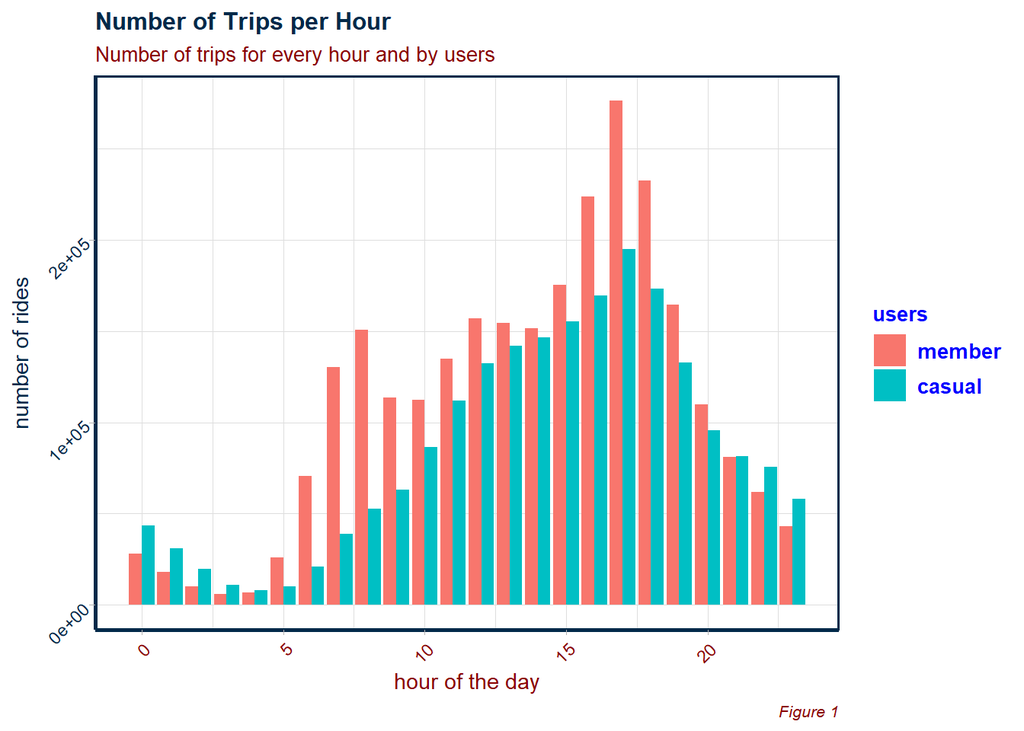

```r
ride_hours %>%
  ggplot(aes(hour_start, nr_rides, fill = users)) + geom_col(position = "dodge") + scale_y_continuous() +
  labs(title = "Number of Trips per Hour", subtitle = "Number of trips for every hour and by users", caption = "Figure 1", x = "hour of the day",             y = "number of rides",) + theme()
```

[figure not shown]

```r
ride_hours %>%
  ggplot(aes(hour_start, average_trip, fill = users))+ geom_col(position = "dodge")+  scale_y_continuous()+
  labs(title = "Average Number of Trips per Hour",subtitle = "Number of trips for every hour segmented by users", caption = "Figure 2",
       x = "hour of the day",y = "average trips duration",)+ theme()
```

### Visualise total_trip time by hours

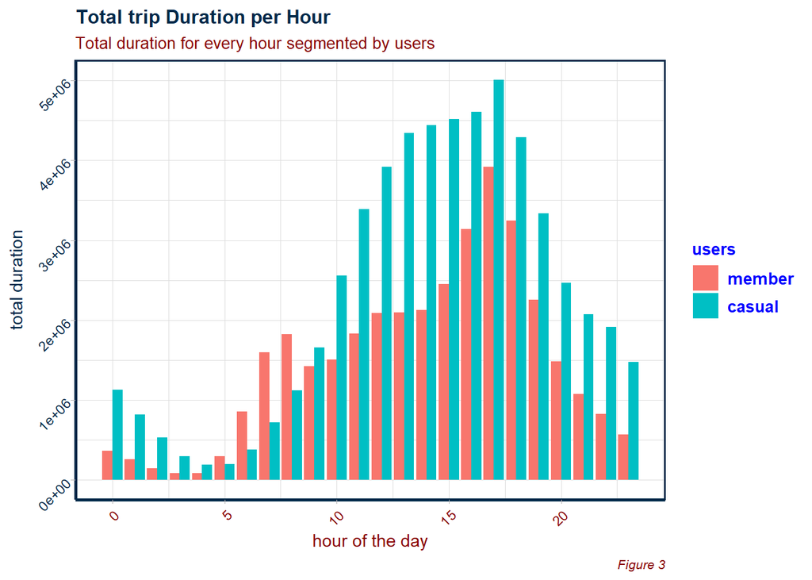

```r
ride_hours %>%
  ggplot(aes(hour_start, total_trip, fill = users))+ geom_col(show.legend = TRUE, position = "dodge")+  scale_y_continuous()+
  labs(title = "Total trip Duration per Hour", subtitle = "Total duration for every hour segmented by users", caption = "Figure 3",
       x = "hour of the day", y = "total duration",)+ theme()
```

### Analysis of days of the week: Create new sumarisation variables nr_rides_week, average_trip_week, total_duration_week.

```r
ride_week <- trips_time_df %>%
  group_by(users, weekday) %>%
  summarise(nr_rides_week = n(), avg_rides_week = mean(trip_time), total_duration_week = sum(trip_time))
```

### Visualise number of trips by weekday

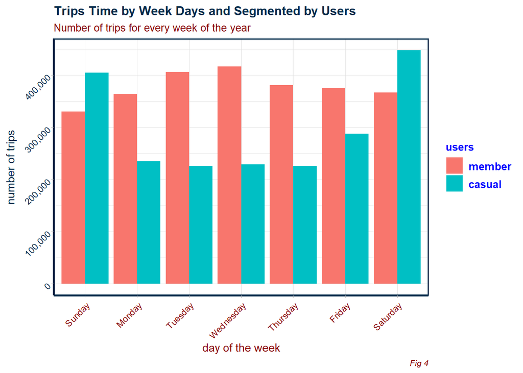

```r
ride_week %>%
  ggplot(aes(weekday, nr_rides_week, fill = users))+ geom_col(position = "dodge")+ scale_y_continuous(labels = comma)+
  labs(title = "Trips Time by Week Days and Segmented by Users", subtitle = "Number of trips for every week of the year", caption = "Fig 4",
    x = "day of the week", y = "number of trips" ,)+ theme()
```

### Visualise average trips time by weekday

[figure not shown]

```r
ride_week %>%
  ggplot(aes(weekday, avg_rides_week, fill = users))+ geom_col(position = "dodge")+ scale_y_continuous(labels = comma)+
  labs(title = "Average Trips Time by Week Days and Segmented by Users", subtitle = "Average Number of trips for every week of the year",
       caption = "Fig 5", x = "day of the week", y = " avg number of trips",)+ theme()
```

### Visualise total trips time by day of the week

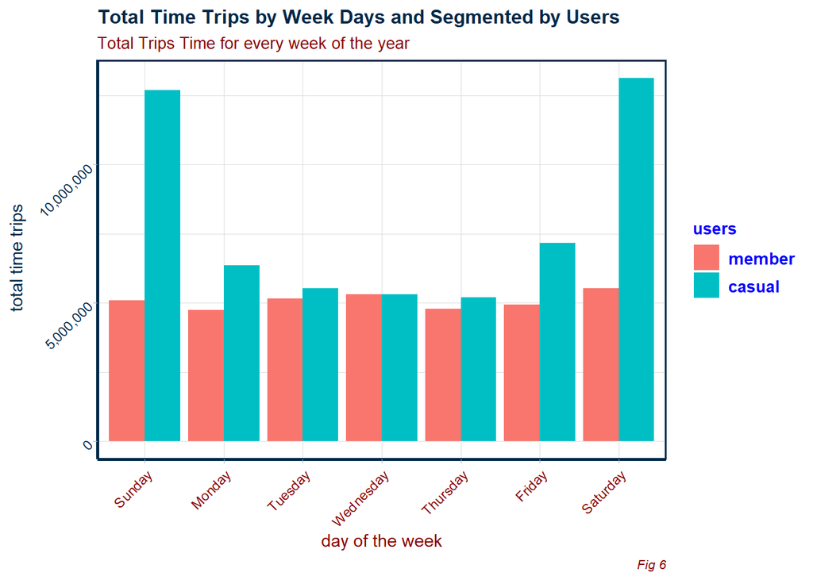

```r
ride_week %>%
  ggplot(aes(weekday, total_duration_week, fill = users))+
  geom_col(position = "dodge")+
  scale_y_continuous(labels = comma)+
  labs(title = "Total Time Trips by Week Days and Segmented by Users", subtitle = "Total Trips Time for every week of the year", caption = "Fig 6",
    x = "day of the week", y = " total time trips",)+ theme()
```

### Analysis of trip time by month

```r
ride_month <- trips_time_df %>%
  group_by(users, month) %>%
  summarise(nr_rides_month = n(), avg_rides_month = mean(trip_time), total_time_month = sum(trip_time))
```

### Visualize number trips by month

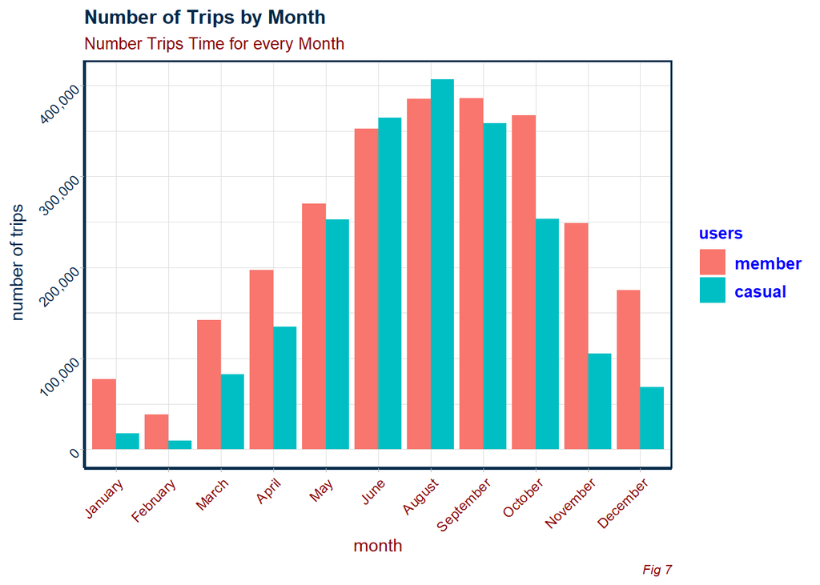

```r
ride_month %>%
  ggplot(aes(month, nr_rides_month, fill = users))+ geom_col(position = "dodge")+ scale_y_continuous(labels = comma)+
  labs(title = "Number of Trips by Month", subtitle = "Number Trips Time for every Month", caption = "Fig 7",x = "month",
      y = " number of trips")+ theme()
```

### Visualise Average trips time by month

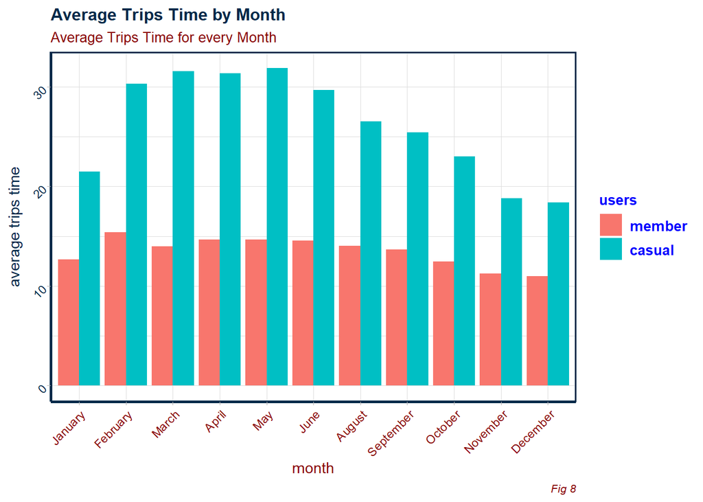

```r
ride_month %>%
  ggplot(aes(month, avg_rides_month, fill = users))+ geom_col(position = "dodge")+ scale_y_continuous(labels = comma)+
  labs(title = "Average Trips Time by Month", subtitle = "Average Trips Time for every Month", caption = "Fig 8", x = "month",
       y = "average trips time")+ theme()
```

### Visualise Total trips time by month

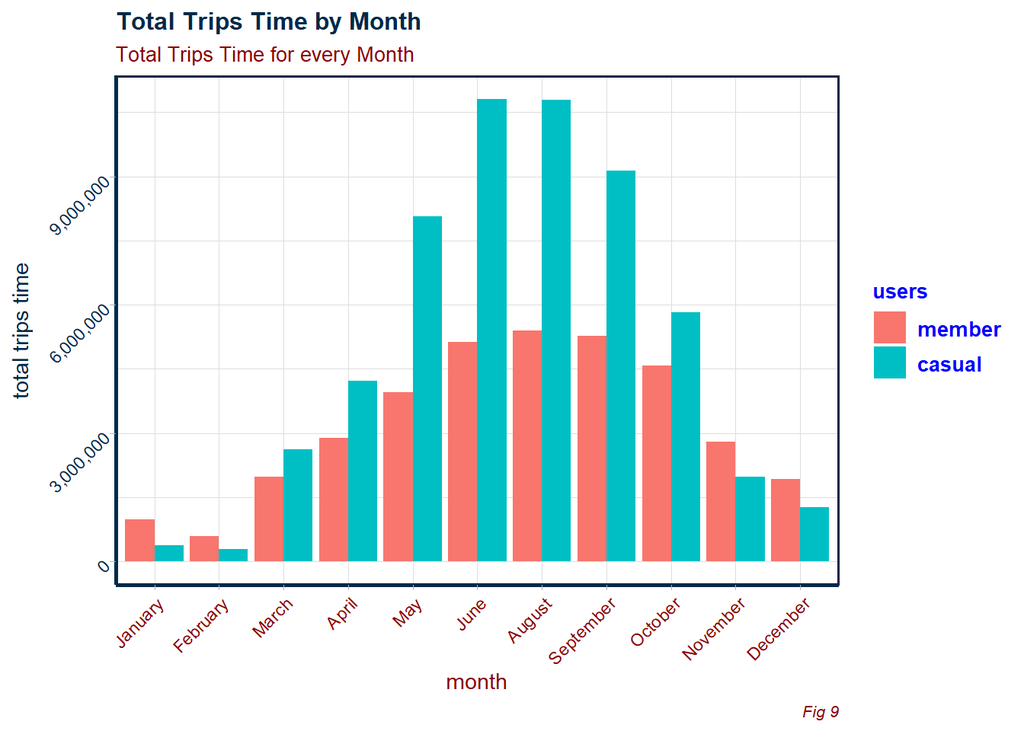

```r
ride_month %>%
  ggplot(aes(month, total_time_month, fill = users))+ geom_col(position = "dodge")+ scale_y_continuous(labels = comma)+
  labs(title = "Total Trips Time by Month ", subtitle = "Total Trips Time for every Month", caption = "Fig 9", x = "month",
       y = "total trips time")+ theme()
```

## Conclusions:

#### From June to August, Casual riders had more rides than membership riders, with Annual riders having more rides from January to May and September to December.

### Average duration

#### The average duration for yearly riders appears to be pretty consistent throughout the year, whereas the average time for casual rides is longer than for membership riders.

### Total duration

#### Casual riders’ total duration is higher from March to October, while membership riders’ total length is higher from January to February and November to December.

### Analysis of trips duration by days of the year

```r
ride_day <- trips_time_df %>%
  group_by(users, day) %>%
  summarise(nr_trips_day = n(), avg_duration_day = mean(trip_time), total_duration_day = sum(trip_time))
```

### Visualisation of number of trips by day

[figure not shown]

```r
ride_day %>%
  ggplot(aes(day, nr_trips_day, fill = users))+ geom_col(position = "dodge")+ scale_y_continuous(labels = comma)+
  labs(title = "Number of Trips per day ", subtitle = "Number of trips per day", caption = "Fig 10", x = "number of trips",             y = "day")+ theme()
```

### Visualisation of average trip length by day

[figure not shown]

```r
ride_day %>%
  ggplot(aes(day, avg_duration_day, fill = users))+ geom_col(position = "dodge")+ scale_y_continuous(labels = comma)+
  labs(title = "Average Trip Time per day ", subtitle = "Length of trips per day", caption = "Fig 11", x = "avg trip duration",
       y = "day")+ theme()
```

### Visualisation of total trip length by day

[figure not shown]

```r
ride_day %>%
  ggplot(aes(day, total_duration_day, fill = users))+ geom_col(position = "dodge")+ scale_y_continuous(labels = comma)+
  labs(title = "Total Trip Duration per day ", subtitle = "Total trip duration per day", caption = "Fig 12", x = "total trip duration",
       y = "day")+theme()
```

### Visualisation of trips duration for weeks of the year

```r
trip_week <- trips_time_df %>%
  group_by(users, week) %>%
  summarise(nr_trips_week = n(), avg_tdw = mean(trip_time), total_tdw = sum(trip_time))
```

### Visualisation of number of trips per week of year

[figure not shown]

```r
trip_week %>%
  ggplot(aes(week, nr_trips_week, fill = users))+ geom_col(position = "dodge")+ scale_y_continuous(labels = comma)+
  labs(title = "Number of trips per week", subtitle = "Number of Trips per week", caption = "Fig 13",
    x = "number of trips", y = "week" )+ theme()
```

### Visualisation of average trip duration per week of year

[figure not shown]

```r
trip_week %>%
  ggplot(aes(week, avg_tdw, fill = users))+ geom_col(position = "dodge")+ scale_y_continuous(labels = comma)+
  labs(title = "Average of trip duration per week", subtitle = "Average of trips duration per week", caption = "Fig 14",
    x = "average trip duration", y = "week" )+ theme()
```

### Visualisation of total trips duration per week of the year

[figure not shown]

```r
trip_week %>%
  ggplot(aes(week, total_tdw, fill = users))+ geom_col(position = "dodge")+ scale_y_continuous(labels = comma)+
  labs(title = "Total trip duration per week", subtitle = "Total of trips duration per week", caption = "Fig 15",
    x = "total trip duration", y = "week")+ theme()
```

## Analysis based on type of bikes

```r
ride_bikes <- trips_time_df %>%
  group_by(users, bikes) %>%
  summarise(nr_bike_ride = n(), avg_bike_ride = mean(trip_time), total_bike_ride = sum(trip_time))
```

### Visualise number of rides by bike type.

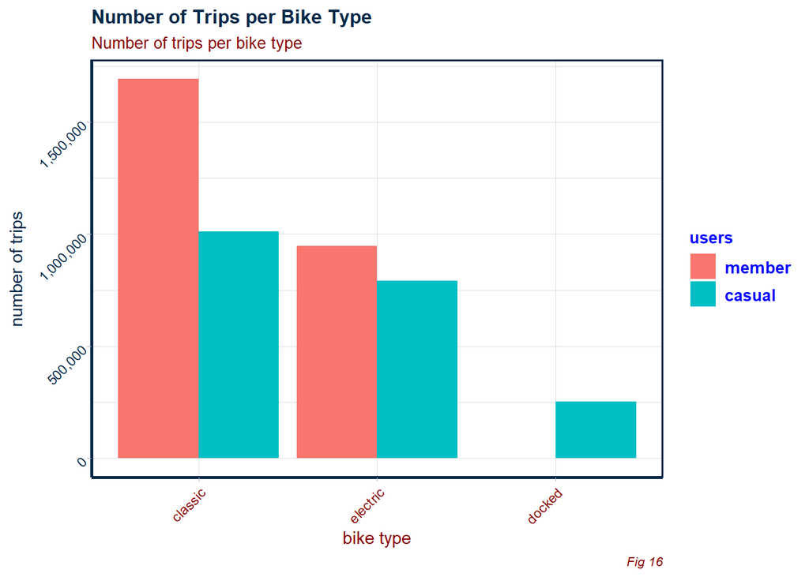

```r
ride_bikes %>%
  ggplot(aes(bikes,nr_bike_ride, fill = users))+ geom_col(position = "dodge")+ scale_y_continuous(labels = comma)+
  labs(title = "Number of Trips per Bike Type", subtitle = "Number of trips per bike type",caption = "Fig 16",
    x = "bike type", y = "number of trips")+ theme()
```

### Visualise the average trip time by bike type

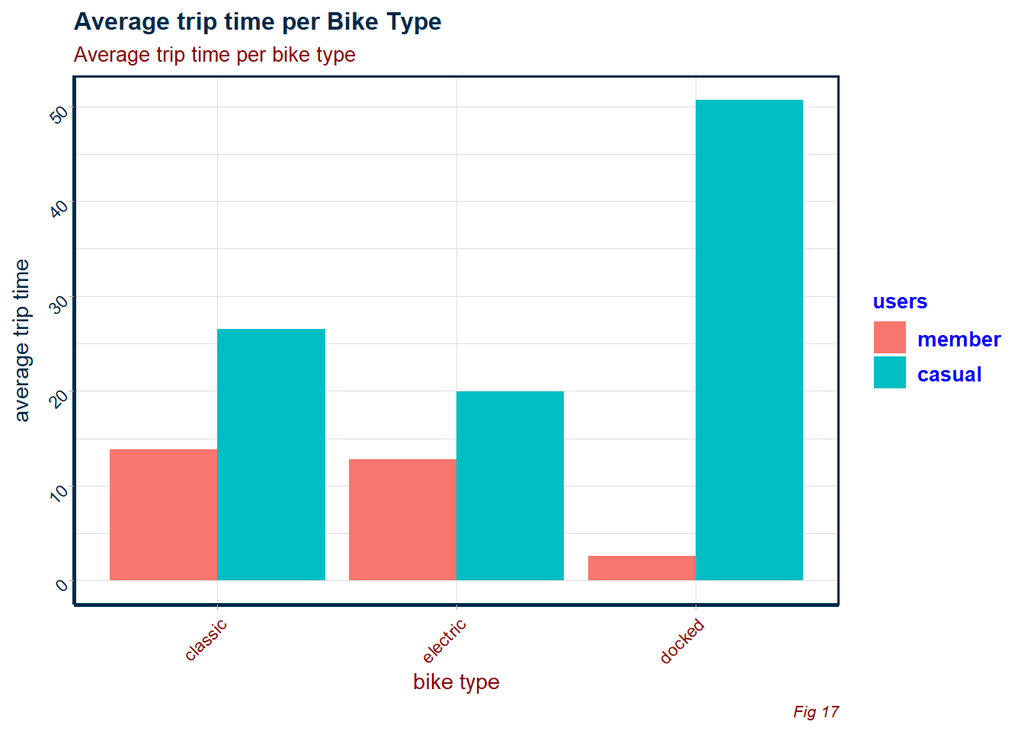

```r
ride_bikes %>%
  ggplot(aes(bikes, avg_bike_ride, fill = users))+ geom_col(position = "dodge")+ scale_y_continuous(labels = comma)+
  labs(title = "Average trip time per Bike Type", subtitle = "Average trip time per bike type", caption = "Fig 17",
       x = "bike type", y = "average trip time")+ theme()
```

### Visualise the total trip time by bike type

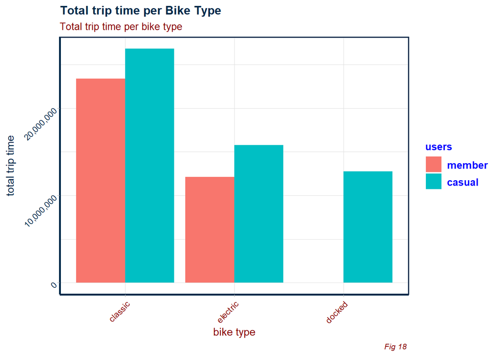

```r
ride_bikes %>%
  ggplot(aes(bikes, total_bike_ride, fill = users))+ geom_col(position = "dodge")+ scale_y_continuous(labels = comma)+
  labs(title = "Total trip time per Bike Type", subtitle = "Total trip time per bike type", caption = "Fig 18 ",
        x = "bike type", y = "total trip time")+ theme()
```

## Conclusions:

### Classic bikes are the most popular among both riders, followed by electric cycles.

### The parked bike (docked) appears to be favoured among casual riders.

## Cyclistic bike analysis by Location

### Analysis structure and column names of the location dataset

```r
head(trips_location_df, 10)
```

```
## # A tibble: 10 × 9
##    ride_id start_station_n… end_station_name start_lat start_lng end_lat end_lng
##    <chr>   <chr>            <chr>                <dbl>     <dbl>   <dbl>   <dbl>
##  1 89E7AA… Glenwood Ave & … Sheridan Rd & C…      42.0     -87.7    42.0   -87.7
##  2 0FEFDE… Glenwood Ave & … Bosworth Ave & …      42.0     -87.7    42.0   -87.7
##  3 E6159D… Clark St & Lake… State St & Rand…      41.9     -87.6    41.9   -87.6
##  4 B32D31… Wood St & Chica… Honore St & Div…      41.9     -87.7    41.9   -87.7
##  5 83E463… State St & 33rd… Emerald Ave & 3…      41.8     -87.6    41.8   -87.6
##  6 BDAA7E… Fairbanks St & … LaSalle Dr & Hu…      41.9     -87.6    41.9   -87.6
##  7 295476… Fairbanks St & … Fairbanks St & …      41.9     -87.6    41.9   -87.6
##  8 362087… LaSalle Dr & Hu… LaSalle Dr & Hu…      41.9     -87.6    41.9   -87.6
##  9 21630F… LaSalle Dr & Hu… LaSalle Dr & Hu…      41.9     -87.6    41.9   -87.6
## 10 8B868B… LaSalle Dr & Hu… LaSalle Dr & Hu…      41.9     -87.6    41.9   -87.6
## # … with 2 more variables: users <fct>, trip_time <drtn>
```

```r
colnames(trips_location_df)
```

```
## [1] "ride_id"            "start_station_name" "end_station_name"
## [4] "start_lat"          "start_lng"          "end_lat"
## [7] "end_lng"            "users"              "trip_time"
```

### Data frame trips_location_df grouped

```r
pop_start_station <- trips_location_df %>%
  group_by(users, start_station_name, start_lat, start_lng) %>%
  summarise(nr_rides_start = n()) %>%
  arrange(-nr_rides_start)
```

```
## You can override using the `.groups` argument.
```

```r
head(pop_start_station)
```

```
## # A tibble: 6 × 5
## # Groups:   users, start_station_name, start_lat [6]
##   users  start_station_name       start_lat start_lng nr_rides_start
##   <fct>  <chr>                        <dbl>     <dbl>          <int>
## 1 casual Streeter Dr & Grand Ave       41.9     -87.6          42724
## 2 member Clark St & Elm St             41.9     -87.6          16228
## 3 member Kingsbury St & Kinzie St      41.9     -87.6          14766
## 4 member Wells St & Concord Ln         41.9     -87.6          14636
## 5 casual Theater on the Lake           41.9     -87.6          13882
## 6 casual Millennium Park               41.9     -87.6          13728
```

```r
colSums(is.na(pop_start_station))
```

```
##              users start_station_name          start_lat          start_lng
##                  0                  0                  0                  0
##     nr_rides_start
##                  0
```

# Visualise top 10 most popular start stations

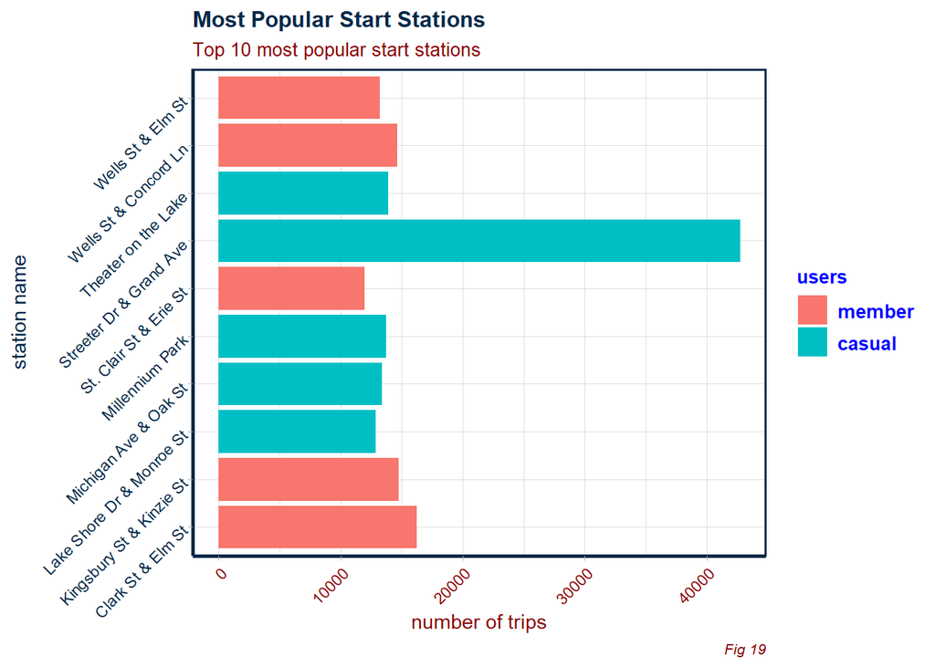

```r
pop_start_station[1:10, ] %>%
  ggplot(aes(start_station_name, nr_rides_start, fill = users))+ geom_col(position = "dodge")+ coord_flip()+
  labs(title = "Most Popular Start Stations", subtitle = "Top 10 most popular start stations", caption = "Fig 19",
       x = "station name", y = "number of trips")+ theme()
```

### Creating Subset of dataframe for analysis

```r
pop_end_station <- trips_location_df %>%
  group_by(users, end_station_name, end_lat, end_lng) %>%
  summarise(nr_rides_end = n()) %>%
  arrange(-nr_rides_end)
```

```
## can override using the `.groups` argument.
```

```r
head(pop_end_station)
```

```
## # A tibble: 6 × 5
## # Groups:   users, end_station_name, end_lat [6]
##   users  end_station_name         end_lat end_lng nr_rides_end
##   <fct>  <chr>                      <dbl>   <dbl>        <int>
## 1 casual Streeter Dr & Grand Ave     41.9   -87.6        45049
## 2 member Clark St & Elm St           41.9   -87.6        16660
## 3 member Wells St & Concord Ln       41.9   -87.6        15482
## 4 casual Theater on the Lake         41.9   -87.6        15352
## 5 member Kingsbury St & Kinzie St    41.9   -87.6        15261
## 6 casual Millennium Park             41.9   -87.6        14664
```

### Visualise top 10 most popular end stations

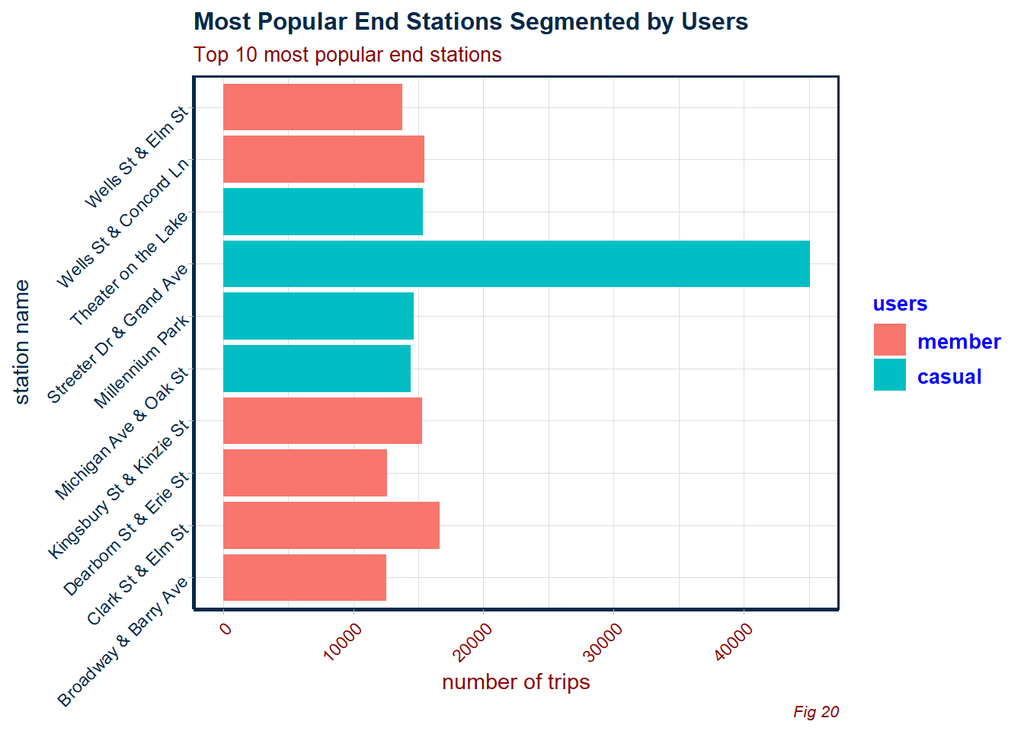

```r
pop_end_station[1:10,] %>%
  ggplot(aes(end_station_name, nr_rides_end, fill = users))+ geom_col(position = "dodge")+ coord_flip()+
  labs(title = "Most Popular End Stations Segmented by Users", subtitle = "Top 10 most popular end stations", caption = "Fig 20",
    x = "station name", y = "number of trips")+ theme()
```

### Mapview of the top 30 most popular start stations

```r
pop_start_station[1:30, ] %>%
  mapview(xcol = "start_lng",  ycol = "start_lat", cex = "nr_rides_start", alpha = 0.9, crs = 4269, color = "#8b0000", grid = F, legend = T,
          layer.name = "30 Most Popular Start Stations")
```

[interactive chart not shown]

### Mapview of the most popular 30 end stations

```r
pop_end_station[1:30,] %>%
  mapview(xcol = "end_lng", ycol = "end_lat", cex = "nr_rides_end", alpha = 0.9, crs = 4269, color = "#8b0000", grid = F, legend = T,
          layer.name = "30 Most Popular End Stations")
```

[interactive chart not shown]

## Conclusions

### The stations that are popular for starting and ending rides differ between members and casual cyclists.

### Top starting and destination stations for casual cyclists cluster around tourist locations within about 1 km of the lakefront. Top stations for member riders are more dispersed and reflect office locations.

## Save and export files for further Analysis

```r
getwd()
```

```
## [1] "C:/Users/hp/OneDrive/Desktop/Data Analysis/Course 8/Project 1/Original files"
```

```r
setwd("C:/Users/hp/OneDrive/Desktop/Data Analysis/Course 8/Project 1/Original files")

 write_csv(trips_5, "cleaned_trips.csv")
 write_csv(trips_time_df, "trips_time_df.csv")
 write_csv(trips_location_df, "trips_location_df.csv")
 write_csv(pop_start_station, "popular_start_station.csv")
 write_csv(pop_end_station, "popular_end_station.csv")
```